# Path

### Rail grinding

In this demo, we look at a rail grinding mechanic where the player jumps over obstacles.

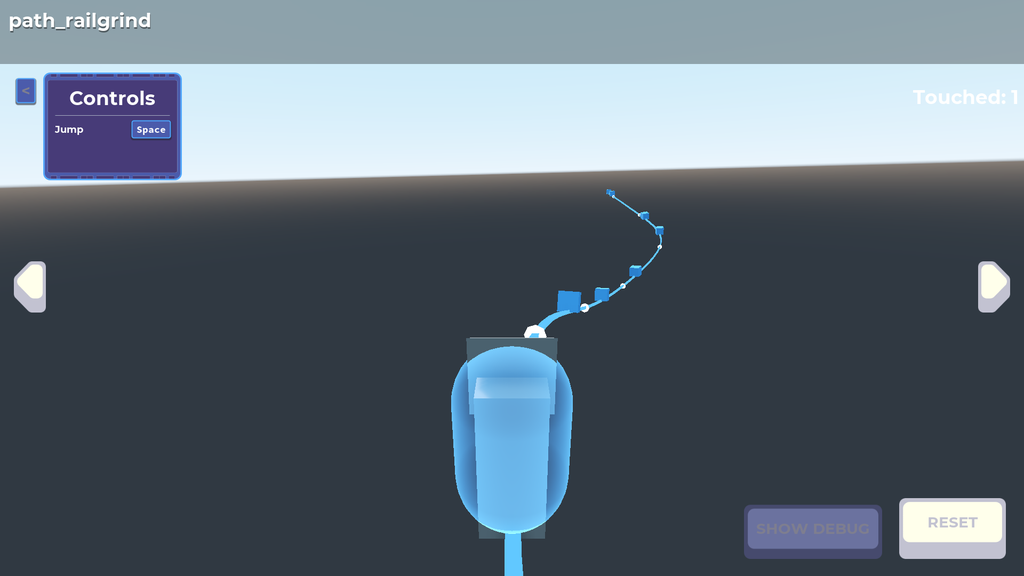

At first glance, the scene setup seems more complicated, but if we focus on the `Path` node and its children, there isn’t much we haven’t already seen here.

The novelty is that we place the `Camera` node under *PlayerGroup* to keep it attached to the player as it moves on the curve.

We keep it independent of the player because we want to jump up and down without having the camera follow this movement.

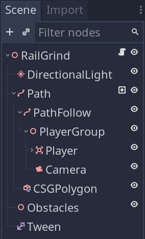

The `CSGPolygon` is used to construct the player’s path, which makes the demo feel “grounded.”

For this setup, instead of using math for the jump mechanic, we’ll use the `Tween` node for the same effect.

We use blue noise to generate non-overlapping random positions to place obstacles along the paths.

The obstacle scene is made out of an `Area` root node with a `MeshInstance` and a `CollisionShape` to detect collisions:

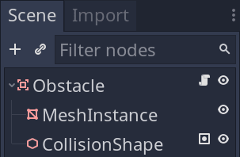

We use a cube for its collision shape:

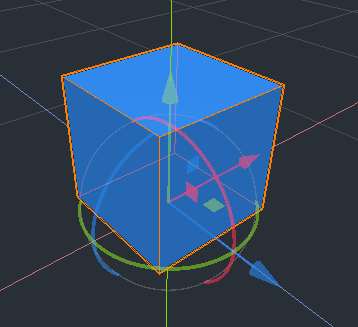

We expose the `MeshInstance` in code so we won’t call `get_node("MeshInstance")` all the time in the demo:

```
onready var mesh_instance: MeshInstance = $MeshInstance
```

We start with declaring the obstacle scene, a few useful constants, and node references:

```
const Obstacle := preload("Obstacle.tscn")

# We change the obstacle color when the player touches it for visual feedback.
const COLORS := {"default": Color("4da6ff"), "touch": Color("eb564b")}
# We generate a number of obstacles between `[OBSTACLES.min, OBSTACLES.max]` per path.
const OBSTACLES := {"min": 5, "max": 11}
const JUMP := {"height": 1, "time": 0.3}
const SPEED := 8

var _rng := RandomNumberGenerator.new()

onready var _path_follow: PathFollow = $Path/PathFollow
onready var _player_group: Spatial = $Path/PathFollow/PlayerGroup
onready var _player: Area = $Path/PathFollow/PlayerGroup/Player
onready var _tween: Tween = $Tween
onready var _obstacles: Spatial = $Obstacles
```

Next, we generate obstacles on the path in `_ready()`:

```
func _ready() -> void:
    _rng.randomize()
    _player.connect("area_entered", self, "_on_Player_area_entered_exited", [true])
    _player.connect("area_exited", self, "_on_Player_area_entered_exited", [false])

    # Generate obstacles on paths.
    for r in _rng_blue_noise(_rng.randi_range(OBSTACLES.min, OBSTACLES.max)):
        _path_follow.unit_offset = r
        var obstacle: Area = Obstacle.instance()
        obstacle.transform = _path_follow.transform
        _obstacles.add_child(obstacle)

    # After placing the obstacles, reset the `PathFollow` offset position.
    _path_follow.unit_offset = 0.0
```

Here’s the blue noise function we use to generate random positions along the path:

```
## Returns an array of the given size with random numbers between `(0, 1)` that have at least
## `padding` distance between them.
func _rng_blue_noise(size: int, padding: float = 0.01) -> Array:
    var out := []
    var cell := 1.0 / size
    for i in range(size):
        var x := padding + cell * i
        out.push_back(_rng.randf_range(x, x + cell - padding))
    return out
```

When the player touches the obstacles, we change their color for visual feedback:

```
func _on_Player_area_entered_exited(area: Area, has_entered: bool) -> void:
    var material: Material = area.mesh_instance.get_active_material(0)
    if has_entered:
        material.albedo_color = COLORS.touch
    else:
        material.albedo_color = COLORS.default
```

We finish with the player controls and movement:

```
func _input(event: InputEvent) -> void:
    if not _tween.is_active() and event.is_action_pressed("jump_3d"):
        _tween.interpolate_property(
            _player, "translation:y", 0, JUMP.height, JUMP.time,Tween.TRANS_QUAD, Tween.EASE_OUT
        )
        _tween.interpolate_property(
            _player, "translation:y", JUMP.height, 0, JUMP.time, Tween.TRANS_QUAD, Tween.EASE_IN,
            JUMP.time
        )
        _tween.start()


func _physics_process(delta: float) -> void:
    _path_follow.offset += SPEED * delta
    if _path_follow.unit_offset >= 1.0:
        set_physics_process(false)
```

**Note:** We use the `Tween` node for the jump animation instead of calculating the trajectory ourselves.

This is possible because jumping under acceleration describes a parabola, and this is what we get when using the `TRANS_QUAD` transition type.